# Logfile oogkleur onderzoek

Cheyenne Brouwer

# Preliminaries

Het onderzoek vond plaats in de maanden mei en juni van het jaar 2023, aan de Hanzehogeschool te Groningen. Er is ook gemeten in Groningen centrum en Zwolle centrum.

# Introduction

## Goal

Het doel van het onderzoek is bekijken of er bij studenten van de Hanzehogeschool Groningen aanleg is voor een bepaalde oogkleur. Daarnaast is er op 2 andere locaties gemeten om verschillen te kunnen onderzoeken in oogkleur en zo te bepalen of er aanleg is voor een bepaalde oogkleur bij studenten van de hogeschool.

## Data collection

De data is verzameld op 3 verschillende locaties, waarbij op elke locatie 40 verschillende proefpersonen zijn bevraagd. De locaties zijn respectievelijk Hanzehogeschool (Van DoorenVeste), Groningen centrum en Zwolle centrum. De proefpersonen zijn in daglicht bevraagd en indien de locatie binnen was bij voorkeur bij goed licht (bij een raam of bij goede TL verlichting). Hier is de oogkleur van de proefpersonen bekeken.

Op de Hanzehogeschool Groningen is de informatie binnen verzameld. In Groningen centrum en Zwolle centrum buiten.

## Theory

### Oorzaak

De oogkleur wordt bepaald door de hoeveelheid en kwaliteit van het pigment melanine in de iris. Melanine wordt geproduceerd door cellen genaamd melanocyten (pigmentcellen). Melanocyten bevinden zich in verschillende delen van het lichaam zoals de huid, het haar en dus ook de ogen. in het oog zitten melanocyten in het bindweefsel. Dit bindweefsel wordt stroma genoemd. De hoeveelheid melanocyten is ongeacht de oogkleur gelijk bij iedereen. Er is dus geen verband tussen de hoeveelheid melanocyten en de oogkleur, maar wel tussen de hoeveelheid en kwaliteit van melanine in de iris. Dit zorgt voor de vele variaties in oogkleuren.

### Verschillen in oogkleur

Mensen met een bruine iris hebben over het algemeen meer melanine in hun ogen t.o.v. mensen met een blauwe/groene iris. Dit komt doordat mensen met een bruine iris in de voorste laag en het stroma van de iris meer melanocyten en melanosomen hebben dan mensen met een blauwe/groene iris. Melanosomen zijn celorganellen die zich in de melanocyten bevinden. Hierin wordt het pigment opgeslagen. Zowel melanocyten als melanosomen zijn verantwoordelijk voor de productie van melanine. Wanneer licht door een grote hoeveelheid melanine gaat, wordt het meeste zichtbare licht geabsorbeerd en een klein deel teruggekaatst, dit zorgt voor de bruine kleur van de iris. Bij weinig aanwezigheid van melanine is de oogkleur lichter, zoals blauw of groen. Als er te weinig melanine is om een sterke kleur blauw te produceren worden de kleuren van bloedvaten (rood) en de kleine hoeveelheid blauwe pigment weerkaatst wat voor een violet kleur zorgt. Er zijn ook gevallen waarbij er helemaal geen melanine aanwezig is, dit wordt ook wel albinisme genoemd. Bij gebrek aan melanine ontstaan er rode ogen. Een rode iris is zoals eerder uitgelegd een weerkaatsing van de bloedvaten in het oog.

### Expressie en dominantie

Ogen zijn er in verschillende soorten blauw, bruin en groen. Het allel dat verantwoordelijk is voor de kleur bruin is dominant over het allel voor blauw en het allel voor groen. Hierbij is het allel voor groen weer dominant over blauw. Een verminderde expressie kan voor een onvolledige dominantie zorgen. Dit veroorzaakt de vele verschillende kleuren van de iris zoals hazelnoot en lichtere tinten bruin.

### Heterochromie

Het kan ook voorkomen dat de iris zelf uit verschillende kleuren bestaat. Dit wordt heterochromie genoemd. Deze aandoening wordt geërfd of veroorzaakt door somatische mutaties in de cellen (bij somatische mutaties vinden er mutaties plaats in cellen die niet betrokken zijn bij geslachtscellen). Het is ook mogelijk dat de aandoening wordt veroorzaakt door (gedeeltelijke) inactivatie van bepaalde genen in de cellen. Hierdoor wordt er op sommige plaatsen in het iris minder pigment geproduceerd dan op andere plaatsen en ontstaat er een iris met meer dan 1 kleur.

# Experimental work

Er is van 3x 40 proefpersonen de oogkleur, het geslacht en de leeftijd verzameld. De oogkleur is van zowel het linker- als rechteroog genoteerd en verwerkt in een spreadsheet. Deze spreadsheet is omgezet in een .csv bestand zodat deze ingelezen kan worden in R markdown.

## Logboek

### 11-05-2023 09:00 - 10:00 - ALL

Gedurende 1 uur zijn op de Hanzehogeschool Groningen (Van DoorenVeste) 40 verschillende studenten bevraagd naar leeftijd en geslacht. Daarna is door 4 verschillende analisten van al deze proefpersonen zowel de rechter- als linkeroogkleur genoteerd bij de identifier van de proefpersoon. Hierbij is gezorgd voor een goede verdeling tussen mannen en vrouwen.

### 11-05-2023 10:45 - 12:00 - ALL

Gedurende 1 uur zijn in Grongingen centrum 40 verschillende proefpersonen bevraagd naar leeftijd en geslacht. Daarna is door 4 verschillende analisten van al deze proefpersonen zowel de rechter- als linkeroogkleur genoteerd bij de identifier van de proefpersoon. Hierbij is gezocht naar proefpersonen die een verwachtte leeftijd hadden van 16 - 30 jaar (studentenleeftijd) en is gezorgd voor een goede verdeling tussen mannen en vrouwen.

### 12-05-2023 14:00 - 16:00 - 399308 (Cheyenne Brouwer)

Gedurende 2 uur is student met studentnummer 399308 bezig geweest met het omzetten van de gegevens per analist in één spreadsheet. Deze spreadsheet is daarna opgeslagen op OneDrive.

### 15-05-2023 13:30 - 15:30 - ALL

Gedurende 2 uur zijn in Zwolle centrum 40 verschillende proefpersonen bevraagd naar leeftijd en geslacht. Daarna is door 4 verschillende analisten van al deze proefpersonen zowel de rechter- als linkeroogkleur genoteerd bij de identifier van de proefpersoon. Hierbij is gezocht naar proefpersonen die een verwachtte leeftijd hadden van 16 - 30 jaar (studentenleeftijd) en is gezorgd voor een goede verdeling tussen mannen en vrouwen.

### 15-05-2023 18:00 - 20:00 - 399308 (Cheyenne Brouwer)

Gedurende 2 uur is student met studentnummer 399308 bezig geweest met het omzetten van de gegevens per analist in één spreadsheet. Het bestand is daarna opgeslagen als. csv bestand zodat deze ingelezen kan worden in R markdown.

# Notatiewijze en opslag

De gegevens per identifier worden als volgt genoteerd in de spreadsheet met als naam spreadsheet_oogkleur.xlsx. Dit bestand wordt opgeslagen op een github die is aangemaakt voor het onderzoek. Deze heet wetenschappelijke_cyclus. De verkregen data wordt verwerkt in het onderzoek en wordt voor de komende 5 jaar opgeslagen.

De data wordt op twee manieren opgeslagen:

Identifier,geslacht,leeftijd,L_OK9308,R_OK9308,L_OK2193,R_OK2193,L_OK5609,R_OK5609,L_OK8705,R_OK8705 001,F,blauw,grijs,blauw,blauw,blauw,blauw,groen,groen

analist,identifier,geslacht,leeftijd,OK_L,OK_R 9308,001,F,blauw,grijs

### Legenda:

OK: oogkleur L: links R: rechts

F (Female): Vrouwelijke studenten M (Male): Mannelijke studenten X: Onzijdige studenten/onbekend

Data was gelezen van bestand:

```r
data <- read.table(file = "/Users/cheyennebrouwer/Downloads/Oogkleur_simpel.csv", header = T, sep = ",")
dim(data)
```

```
## [1] 120  11
```

```r
head(data)
```

```
##   Identifier geslacht leeftijd L_OK9308 R_OK9308 L_OK2193 R_OK2193 L_OK5609
## 1       A001        M       20    blauw    blauw    blauw    blauw    blauw
## 2       A002        F       19    hazel    hazel    hazel    hazel    hazel
## 3       A003        F       22    bruin    bruin    bruin    bruin    bruin
## 4       A004        M       20    blauw    blauw    blauw    blauw    blauw
## 5       A005        M       17    bruin    bruin    bruin    bruin    bruin
## 6       A006        M       20    blauw    blauw    blauw    blauw    blauw
##   R_OK5609 L_OK8705 R_OK8705
## 1    blauw    blauw    blauw
## 2    hazel    groen    groen
## 3    bruin    bruin    bruin
## 4    blauw    blauw    blauw
## 5    bruin    bruin    bruin
## 6    blauw    blauw    blauw
```

Data ziet er OK uit. De data dimensies en data types zijn in overeenstemming met wat werd verwacht.

### 24-05-2023 10:00 - 10:30 399308(Cheyenne) en 5609(Demi)

Setup chunck is aangemaakt zodat alle benodigde libraries bij alle chuncks gebruikt kunnen worden.

Nieuwe bestand is ingelezen. De output komt overeen met de verwachtingen. Later is deze output echter niet gebruikt, omdat het uiteindelijke bestand beter omgezet kon worden met het originele bestand in plaats van de nieuwe versie.

```r
data <- read.table(file ="/Users/cheyennebrouwer/Documents/22_23/Kwartaal_4/wetenschappelijke_cyclus/Oogkleur_simpel2.csv", header = T, sep = ",")
head(data)
```

[output not shown]

### 28-05-2023 19:00 - 21:00 399308(Cheyenne) en 415069(Demi)

Bestand is wederom ingelezen en is omgezet naar een definitieve versie. Per identifier is er een definitieve oogkleur bepaald, die zichtbaar is onder de kolom “results”. Indien er geen duidelijke meerderheid voor de oogkleur van een identifier is door verschillende metingen, wordt de oogkleur onder undefined gezet. Undefined betekent dat de verzamelde data te divers was om tot een definitief besluit voor oogkleur te kunnen komen.

```r
file <- "/Users/cheyennebrouwer/Downloads/Oogkleur_simpel.csv"

eye_colors <- read.table(file, sep= ",", header=T)
head(eye_colors)
```

```
##   Identifier geslacht leeftijd L_OK9308 R_OK9308 L_OK2193 R_OK2193 L_OK5609
## 1       A001        M       20    blauw    blauw    blauw    blauw    blauw
## 2       A002        F       19    hazel    hazel    hazel    hazel    hazel
## 3       A003        F       22    bruin    bruin    bruin    bruin    bruin
## 4       A004        M       20    blauw    blauw    blauw    blauw    blauw
## 5       A005        M       17    bruin    bruin    bruin    bruin    bruin
## 6       A006        M       20    blauw    blauw    blauw    blauw    blauw
##   R_OK5609 L_OK8705 R_OK8705
## 1    blauw    blauw    blauw
## 2    hazel    groen    groen
## 3    bruin    bruin    bruin
## 4    blauw    blauw    blauw
## 5    bruin    bruin    bruin
## 6    blauw    blauw    blauw
```

```r
majority2 <- function(x) {
    #print(as.character(x))
    #return("A")
    t <- table(x)
    if (length(t) == 1) return(x[1])
    else if(length(unique(t)) == 1) return("Undef.")
    else{
        df <- as.data.frame(t)
        #print(df)
        return(as.character(df[order(df$Freq, decreasing = T)[1], 1]))
    }
}

eye_colors2 <- eye_colors %>%
    rowwise() %>%
    mutate(results = majority2(c_across(4:11))) %>%
    pivot_longer(cols = contains("_"),
               names_pattern = "(L|R)_OK(.+)",
               names_to = c("Eye", "Laborant"),
               values_to = "color")

head(eye_colors2, n = Inf)
```

```
## # A tibble: 960 × 7
##    Identifier geslacht leeftijd results Eye   Laborant color
##    <chr>      <chr>       <int> <chr>   <chr> <chr>    <chr>
##  1 A001       M              20 blauw   L     9308     blauw
##  2 A001       M              20 blauw   R     9308     blauw
##  3 A001       M              20 blauw   L     2193     blauw
##  4 A001       M              20 blauw   R     2193     blauw
##  5 A001       M              20 blauw   L     5609     blauw
##  6 A001       M              20 blauw   R     5609     blauw
##  7 A001       M              20 blauw   L     8705     blauw
##  8 A001       M              20 blauw   R     8705     blauw
##  9 A002       F              19 hazel   L     9308     hazel
## 10 A002       F              19 hazel   R     9308     hazel
## # ℹ 950 more rows
```

### **Deelvraag: “Is er een aantoonbaar verschil in oogkleur tussen de verschillende locaties waarop gemeten is?”**

### 01-06-2023 399308(Cheyenne) 18:00 - 20:00

In het bestand is er per identifier de bijbehorende locatie toegevoegd.

```r
eye_colors_location <- eye_colors2 %>%
  mutate(location = case_when(
    row_number() <= 320 ~ "Hanze Hogeschool Groningen",
    row_number() <= 640 ~ "Groningen centrum",
    row_number() <= 960 ~ "Zwolle centrum",
    TRUE ~ NA_character_
  ))
eye_colors_location
```

```
## # A tibble: 960 × 8
##    Identifier geslacht leeftijd results Eye   Laborant color location
##    <chr>      <chr>       <int> <chr>   <chr> <chr>    <chr> <chr>
##  1 A001       M              20 blauw   L     9308     blauw Hanze Hogeschool G…
##  2 A001       M              20 blauw   R     9308     blauw Hanze Hogeschool G…
##  3 A001       M              20 blauw   L     2193     blauw Hanze Hogeschool G…
##  4 A001       M              20 blauw   R     2193     blauw Hanze Hogeschool G…
##  5 A001       M              20 blauw   L     5609     blauw Hanze Hogeschool G…
##  6 A001       M              20 blauw   R     5609     blauw Hanze Hogeschool G…
##  7 A001       M              20 blauw   L     8705     blauw Hanze Hogeschool G…
##  8 A001       M              20 blauw   R     8705     blauw Hanze Hogeschool G…
##  9 A002       F              19 hazel   L     9308     hazel Hanze Hogeschool G…
## 10 A002       F              19 hazel   R     9308     hazel Hanze Hogeschool G…
## # ℹ 950 more rows
```

Hieronder is de data verdeeld in de 3 locaties, waarbij Hanze voor Hanze Hogeschool Groningen staat, Centrum voor centrum Groningen staat en Zwolle voor centrum Zwolle staat. Per locatie is er ook nog gekeken naar de verdeling tussen man en vrouw, maar deze data is verderop niet gebruikt. Er is voor gekozen om deze data niet te gebruiken, omdat het voor het beantworrden van de deelvraag niet een vereiste was

Het bestand is zo aangepast dat er per identifier 1 uiteindelijke oogkleur staat onder de kolom “results”, met voor elke identifier de bijbehorende locatie. Hierdoor is de bestandslengte aangepast van 960 datapunten naar 120 datapunten, wat ook het correcte aantal identifiers is.

```r
Total_amount <- eye_colors_location %>%
  group_by(Identifier) %>%
  slice(1)
Total_amount
```

```
## # A tibble: 120 × 8
## # Groups:   Identifier [120]
##    Identifier geslacht leeftijd results Eye   Laborant color location
##    <chr>      <chr>       <int> <chr>   <chr> <chr>    <chr> <chr>
##  1 A001       M              20 blauw   L     9308     blauw Hanze Hogeschool G…
##  2 A002       F              19 hazel   L     9308     hazel Hanze Hogeschool G…
##  3 A003       F              22 bruin   L     9308     bruin Hanze Hogeschool G…
##  4 A004       M              20 blauw   L     9308     blauw Hanze Hogeschool G…
##  5 A005       M              17 bruin   L     9308     bruin Hanze Hogeschool G…
##  6 A006       M              20 blauw   L     9308     blauw Hanze Hogeschool G…
##  7 A007       M              25 hazel   L     9308     hazel Hanze Hogeschool G…
##  8 A008       M              18 blauw   L     9308     blauw Hanze Hogeschool G…
##  9 A009       M              18 blauw   L     9308     blauw Hanze Hogeschool G…
## 10 A010       F              23 blauw   L     9308     blauw Hanze Hogeschool G…
## # ℹ 110 more rows
```

Voor de data van de Hanze Hogeschool Groningen zijn de eerste 40 datapunten nodig. In de onderstaande code worden de eerste 40 data punten van het bestand gepakt, om vervolgens als resultaat de oogkleuren op de Hanze Hogeschool Groningen met de bijbehorende aantallen te krijgen. Uit de resultaten komen 40 getelde oogkleuren, wat ook het correcte aantal is. Er is 1 identifier met een oogkleur die gecategoriseerd is als undefined.

```r
Hanze_amount <- Total_amount[1:40, ]

Hanze <- Hanze_amount %>%
  group_by(results) %>%
  summarise(count = n()) %>%
  arrange(results, desc(count))
Hanze
```

[output not shown]

Uit de data van de Hanze Hogeschool Groningen is er gesorteerd op de hoeveelheden van oogkleur per geslacht met de bijbehorende aantallen per kleur.

```r
Hanze_gender <- Hanze_amount %>%
  group_by(results, geslacht) %>%
  summarise(count = n(), .groups = "drop") %>%
  arrange(results, geslacht, desc(count))
Hanze_gender
```

[output not shown]

Voor de data van het centrum van Groningen zijn datapunten 41 tot en met 80 nodig. In de onderstaande code worden de datapunten van 41 tot en met 80 van het bestand gepakt, om vervolgens als resultaat de oogkleuren in het centrum van Groningen met de bijbehorende aantallen te krijgen. Uit de resultaten komen 40 getelde oogkleuren, wat ook het correcte aantal is. Er zijn 2 identifiers met een oogkleur die gecategoriseerd is als undefined.

```r
Centrum_amount <- Total_amount[41:80, ]

Centrum <- Centrum_amount %>%
  group_by(results) %>%
  summarise(count = n()) %>%
  arrange(results, desc(count))
Centrum
```

[output not shown]

Uit de data van het centrum van Groningen is er gesorteerd op de hoeveelheden van oogkleur per geslacht met de bijbehorende aantallen per kleur.

```r
Centrum_gender <- Centrum_amount %>%
  group_by(results, geslacht) %>%
  summarise(count = n(), .groups = "drop") %>%
  arrange(results, geslacht, desc(count))
Centrum_gender
```

[output not shown]

Voor de data van het centrum van Zwolle zijn datapunten 81 tot en met 120 nodig. In de onderstaande code worden de datapunten van 81 tot en met 120 van het bestand gepakt, om vervolgens als resultaat de oogkleuren in het centrum van Zwolle met de bijbehorende aantallen te krijgen. Uit de resultaten komen 40 getelde oogkleuren, wat ook het correcte aantal is. Er zijn 5 identifiers met een oogkleur die gecategoriseerd is als undefined.

```r
Zwolle_amount <- Total_amount[81:120, ]

Zwolle <- Zwolle_amount %>%
  group_by(results) %>%
  summarise(count = n()) %>%
  arrange(results, desc(count))
Zwolle
```

[output not shown]

Uit de data van het centrum van Zwolle is er gesorteerd op de hoeveelheden van oogkleur per geslacht met de bijbehorende aantallen per kleur.

```r
Zwolle_gender <- Zwolle_amount %>%
  group_by(results, geslacht) %>%
  summarise(count = n(), .groups = "drop") %>%
  arrange(results, geslacht, desc(count))
Zwolle_gender
```

[output not shown]

### 02-06-2023 399308(Cheyenne) 9:00 - 11:30

Er is per locatie een bijpassende pie chart gemaakt, waarin de verdeling van de oogkleuren per locatie weergegeven wordt.

```r
ggplot(data = Hanze,
       aes(x = "", y = count, fill = results)) +
  geom_col(color = "black") +
  coord_polar(theta = "y") +
  geom_label(aes(label = count),
             position = position_stack(vjust = 0.5),
             show.legend = F) +
  ggtitle("Verdeling van oogkleur op de Hanze Hogeschool Groningen") +
  labs(caption = "Taart grafiek die de verdeling van de oogkleur op de Hanze Hogeschool Groningen weergeeft.")
```

[output not shown]

```r
ggplot(data = Hanze_gender,
       mapping = aes(x=results, y=count, col = geslacht, fill = geslacht, group = geslacht)) +
  geom_bar(stat = "identity", position = "dodge") +
  ggtitle("Hanze_gender") +
  geom_text(aes(label=count), position=position_dodge(width=0.9), vjust=-0.25, color = "black")
```

[output not shown]

```r
ggplot(data = Centrum,
       aes(x = "", y = count, fill = results)) +
  geom_col(color = "black") +
  coord_polar(theta = "y") +
  geom_label(aes(label = count),
             position = position_stack(vjust = 0.5),
             show.legend = F) +
  ggtitle("Verdeling van oogkleur in het centrum van Groningen") +
  labs(caption = "Taart grafiek die de verdeling van de oogkleur in het centrum van Groningen weergeeft.")
```

[output not shown]

```r
ggplot(data = Centrum_gender,
       mapping = aes(x=results, y=count, col = geslacht, fill = geslacht, group = geslacht)) +
  geom_bar(stat = "identity", position = "dodge") +
  ggtitle("centrum_gender") +
  geom_text(aes(label=count), position=position_dodge(width=0.9), vjust=-0.25, color = "black")
```

[output not shown]

```r
ggplot(data = Zwolle,
       aes(x = "", y = count, fill = results)) +
  geom_col(color = "black") +
  coord_polar(theta = "y") +
  geom_label(aes(label = count),
             position = position_stack(vjust = 0.5),
             show.legend = F) +
  ggtitle("Verdeling van oogkleur in het centrum van Zwolle") +
  labs(caption = "Taart grafiek die de verdeling van de oogkleur in het centrum van Zwolle weergeeft.")
```

[output not shown]

```r
ggplot(data = Zwolle_gender,
       mapping = aes(x=results, y=count, col = geslacht, fill = geslacht, group = geslacht)) +
  geom_bar(stat = "identity", position = "dodge") +
  ggtitle("zwolle_gender") +
  geom_text(aes(label=count), position=position_dodge(width=0.9), vjust=-0.25, color = "black")
```

[output not shown]

### 04-06-2023 399308(Cheyenne) 12:00 - 14:00

Voor de dataverwerking is gekozen voor de chi-square test met behulp van CrossTable. Er is voor de chi-square test gekozen, omdat met deze test getoetst kan worden of twee categorische variabelen aan elkaar gerelateerd zijn. Bij deze deelvraag is er getoetst of er een relatie is tussen de oogkleur en de locatie waar de oogkleuren gemeten zijn. De CrossTable is gebruikt, omdat dit gebruikt wordt in het boek “Discovering statistics using R”. Hieruit is afgeleid dat de CrossTable ook heel overzichtelijk is en de verkregen data van de chi-square test uitgebreid laat zien. CrossTable laat de waardes zien van alle locaties met de bijbehorende aantallen voor elke oogkleur en undefined, samen met de p-waarde een een overzicht van de totale aantallen per kolom. Een alternatief voor de CrossTable is chisq.test(), maar dit is minder overzichtelijk en laat alleen de p-waarde zien.

```r
eye_endresults <- Total_amount %>%
    rowwise() %>%
    relocate(results, .after = leeftijd) %>%
    relocate(location, .after = Identifier)
eye_endresults
```

```
## # A tibble: 120 × 8
## # Rowwise:  Identifier
##    Identifier location            geslacht leeftijd results Eye   Laborant color
##    <chr>      <chr>               <chr>       <int> <chr>   <chr> <chr>    <chr>
##  1 A001       Hanze Hogeschool G… M              20 blauw   L     9308     blauw
##  2 A002       Hanze Hogeschool G… F              19 hazel   L     9308     hazel
##  3 A003       Hanze Hogeschool G… F              22 bruin   L     9308     bruin
##  4 A004       Hanze Hogeschool G… M              20 blauw   L     9308     blauw
##  5 A005       Hanze Hogeschool G… M              17 bruin   L     9308     bruin
##  6 A006       Hanze Hogeschool G… M              20 blauw   L     9308     blauw
##  7 A007       Hanze Hogeschool G… M              25 hazel   L     9308     hazel
##  8 A008       Hanze Hogeschool G… M              18 blauw   L     9308     blauw
##  9 A009       Hanze Hogeschool G… M              18 blauw   L     9308     blauw
## 10 A010       Hanze Hogeschool G… F              23 blauw   L     9308     blauw
## # ℹ 110 more rows
```

```r
CrossTable(eye_endresults$location, eye_endresults$results, chisq = TRUE, expected = TRUE, format = "SPSS")
```

```
##
##    Cell Contents
## |-------------------------|
## |                   Count |
## |         Expected Values |
## | Chi-square contribution |
## |             Row Percent |
## |          Column Percent |
## |           Total Percent |
## |-------------------------|
##
## Total Observations in Table:  120
##
##                            | eye_endresults$results
##    eye_endresults$location |    blauw  |    bruin  |    groen  |    hazel  |   Undef.  | Row Total |
## ---------------------------|-----------|-----------|-----------|-----------|-----------|-----------|
##          Groningen centrum |       21  |       14  |        1  |        2  |        2  |       40  |
##                            |   21.000  |   10.667  |    3.333  |    2.333  |    2.667  |           |
##                            |    0.000  |    1.042  |    1.633  |    0.048  |    0.167  |           |
##                            |   52.500% |   35.000% |    2.500% |    5.000% |    5.000% |   33.333% |
##                            |   33.333% |   43.750% |   10.000% |   28.571% |   25.000% |           |
##                            |   17.500% |   11.667% |    0.833% |    1.667% |    1.667% |           |
## ---------------------------|-----------|-----------|-----------|-----------|-----------|-----------|
## Hanze Hogeschool Groningen |       22  |       11  |        2  |        4  |        1  |       40  |
##                            |   21.000  |   10.667  |    3.333  |    2.333  |    2.667  |           |
##                            |    0.048  |    0.010  |    0.533  |    1.190  |    1.042  |           |
##                            |   55.000% |   27.500% |    5.000% |   10.000% |    2.500% |   33.333% |
##                            |   34.921% |   34.375% |   20.000% |   57.143% |   12.500% |           |
##                            |   18.333% |    9.167% |    1.667% |    3.333% |    0.833% |           |
## ---------------------------|-----------|-----------|-----------|-----------|-----------|-----------|
##             Zwolle centrum |       20  |        7  |        7  |        1  |        5  |       40  |
##                            |   21.000  |   10.667  |    3.333  |    2.333  |    2.667  |           |
##                            |    0.048  |    1.260  |    4.033  |    0.762  |    2.042  |           |
##                            |   50.000% |   17.500% |   17.500% |    2.500% |   12.500% |   33.333% |
##                            |   31.746% |   21.875% |   70.000% |   14.286% |   62.500% |           |
##                            |   16.667% |    5.833% |    5.833% |    0.833% |    4.167% |           |
## ---------------------------|-----------|-----------|-----------|-----------|-----------|-----------|
##               Column Total |       63  |       32  |       10  |        7  |        8  |      120  |
##                            |   52.500% |   26.667% |    8.333% |    5.833% |    6.667% |           |
## ---------------------------|-----------|-----------|-----------|-----------|-----------|-----------|
##
##
## Statistics for All Table Factors
##
##
## Pearson's Chi-squared test
## ------------------------------------------------------------
## Chi^2 =  13.85774     d.f. =  8     p =  0.08554961
##
##
##
##        Minimum expected frequency: 2.333333
## Cells with Expected Frequency < 5: 9 of 15 (60%)
```

Het resultaat van de chi-square test laat een p-waarde van 0.08 zien. Op basis dat een p-waarde met een waarde lager dan 0.05 significant is, is deze p-waarde dus niet significant.

### 05-06 399308(Cheyenne) 9:30 - 15:00

Discussie: In de data is zichtbaar dat er 3 locaties zijn met 40 proefpersonen per locatie. Deze proefpersonen zijn verdeeld tussen mannen en vrouwen en deze verdeling is exact 50/50. Op alle locaties is er een zichtbare overmaat aan proefpersonen met blauwe ogen, maar op locatie Zwolle zijn er in verhouding een stuk meer proefpersonen met groene ogen dan de andere locaties. De verdeling van bruin en hazel ogen lag op alle locaties ongeveer gelijk, maar in Zwolle liggen de hoeveelheden bruin en hazel iets lager dan in de andere 2 locaties. Aan de p-waarde van 0.08 is zichtbaar dat er is geen significant verschil is tussen de oogkleuren per locatie.

Conclusie: De gemeten locaties hebben geen significante invloed op de waargenomen oogkleuren.

### 11-06 14:00 - 15:30

Eerste versie van abstract is geschreven voor het wetenschappelijk artikel.

### 12-06 8:30 - 15:00

Nieuw figuur is aangemaakt voor in het wetenschappelijke artikel. In dit figuur zijn alle drie locaties naast elkaar geplaats in 3 bar plots. Hierin zijn de verschillen per oogkleur per locatie duidelijk af te lezen. Apart is er nog toegevoegd dat elke bar de juiste kleur heeft, die hoort bij de oogkleur.

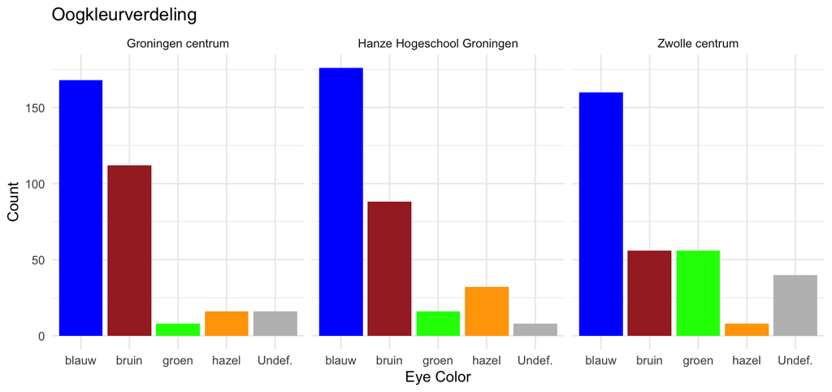

Drie barplots met de drie meetlocaties en aantal gemeten oogkleuren.

```r
ggplot(data = eye_colors_location, aes(x = results, fill = results)) +
  geom_bar() +
  labs(x = "Eye Color", y = "Count", title = "Oogkleurverdeling") +
  theme_minimal() +
  theme(legend.position = "none") +
  scale_fill_manual(values = c("Undef." = "gray", "blauw" = "blue", "bruin" = "brown", "groen" = "green", "hazel" = "orange")) +
  facet_wrap(~ location, nrow = 1)
```